# Comparing Groups

# Authoritarianism and Domestic Policy Attitudes

## Data Description

The first file is just the cleaned western data. The second is the regression models. The third is a list of latent variable models.

[output not shown]

### Estimation and Summarization of Differential Item Functioning in the Authoritarianism Scale

In the analysis folder, there is a file called “latent.R” which executes six IRT models. The model scripts are located here:

~/analysis/latent.R

The model estimates – they take a bit to run – are located in the tmp folder:

~/tmp/models.rda

The estimates – a list – include these six models:

The two parameter IRT model is:

$$\begin{align*}
P(X_{ij} = 1) &= \frac{1}{1 + \exp(\alpha_j ( \beta_j) -
\theta_{i})}
\end{align*}$$

Inside the parentheses: the difference between the latent variable and the item easiness. Multiply this by the discrimination parameter, or how discriminating the item is across levels of the latent variable.

The DIF model is

$$\begin{align*}
P(X_{ij} = 1) &= \frac{1}{1 + \exp(\alpha_{j,k} (\beta_{j,k} +
\gamma_{k,i}))}
\end{align*}$$

This is generally correct, but it’s often noted that the model is not identified. One solution is to fix the mean and variance of the latent variable to 0 and 1, respectively. In the Bayesian context, this is achieved by specifiying strong priors; in this case, a normal distribution with a mean of 0 and a standard deviation of 1.

The model is written as a brms multilevel model; where responses are nested in item – defined by two characteristics: easiness and discrimination – and the and also depends on the latent variable. The model simply changes by adding a group level indicator to the item easiness and discrimination parameters.

To explore parameters in Shiny:

```r
#launch_shinystan(models[[1]])
```

Here is the fully varying – i.e., DIF model – and the no DIF model.

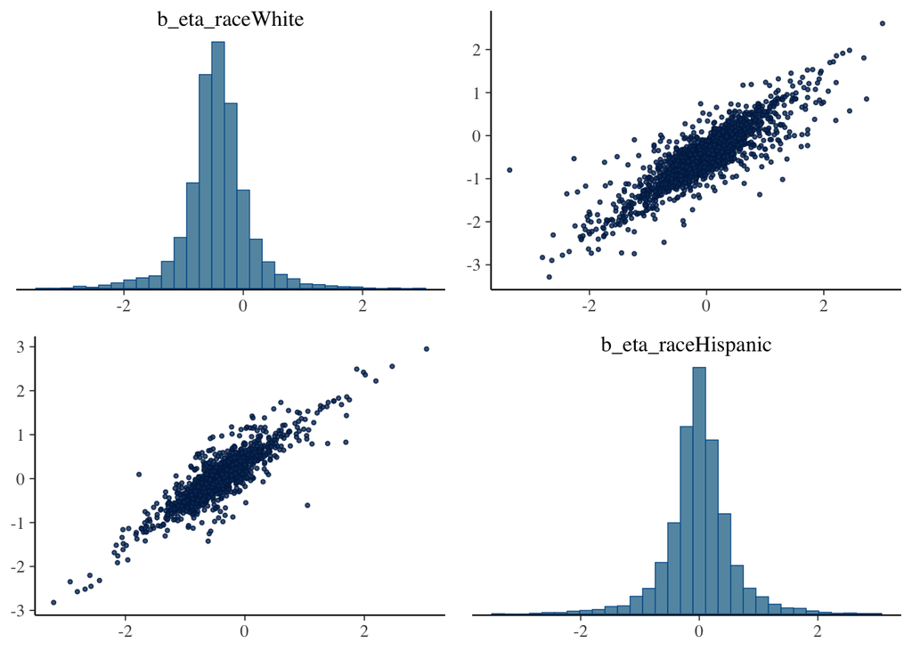

```r
options(repr.plot.width = 12, repr.plot.height = 6)

difM1 = models[[1]]
difM2 = models[[2]]
difM3 <- models[[3]]
difM4 <- models[[4]]
difM5 <- models[[5]]
difM6 <- models[[6]]
# Plot the model
div_style <- parcoord_style_np(div_color = "green", div_size = 10, div_alpha = 0.4)

nn <- nuts_params(difM1)

theme_set(theme_default() + plot_bg(fill = "white", color = "transparent"))

mcmc_pairs(difM1,
  pars = c("b_eta_raceWhite", "b_eta_raceHispanic"),
  np = nn,
  off_diag_args = list(size = 0.75),
  np_style = div_style
)
```

```r
mcmc_trace(difM1, pars = c("b_eta_raceWhite", "b_eta_raceHispanic"), np = nn) +
  xlab("Post-warmup iteration") + labs(title = "differential item functioning model")
```

```
## No divergences to plot.
```

[figure not shown]

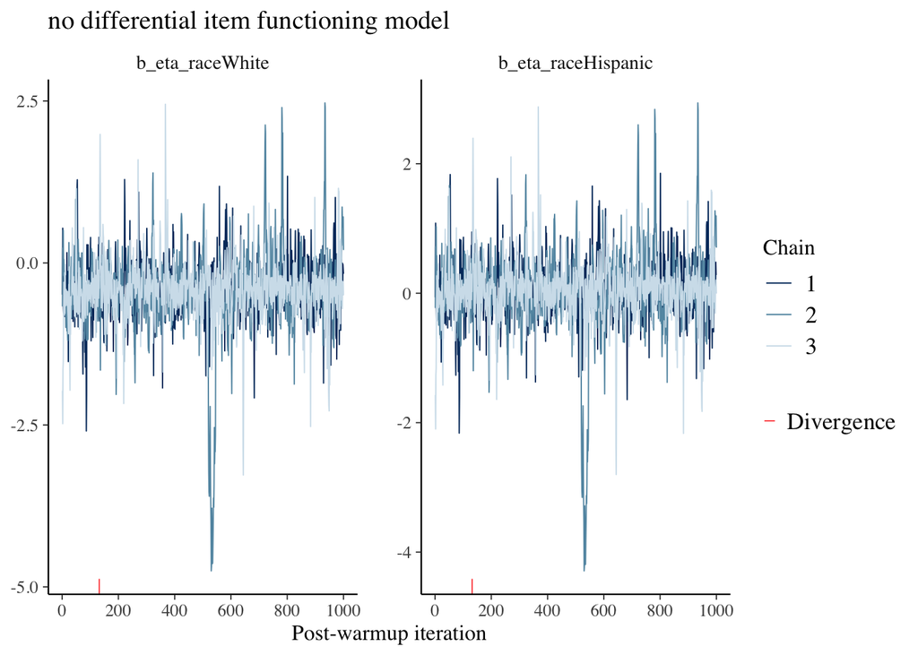

```r
# Plot the model
div_style <- parcoord_style_np(div_color = "green", div_size = 10, div_alpha = 0.4)

nn <- nuts_params(difM2)

theme_set(theme_default() + plot_bg(fill = "white", color = "transparent"))


mcmc_trace(difM2, pars = c("b_eta_raceWhite", "b_eta_raceHispanic"), np = nn) +
  xlab("Post-warmup iteration") + labs(title = "no differential item functioning model")
```

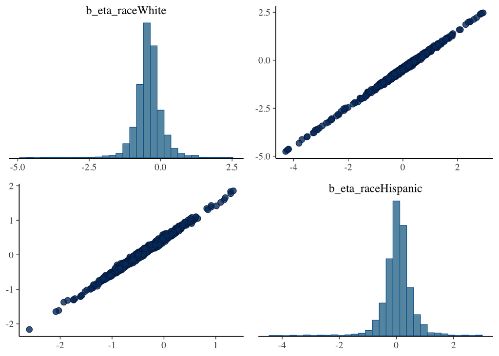

```r
  mcmc_pairs(difM2,
    pars = c("b_eta_raceWhite", "b_eta_raceHispanic"),

  )
```

```r
loo(difM1, difM2)
```

```
## Output of model 'difM1':
##
## Computed from 4500 by 12790 log-likelihood matrix
##
##          Estimate    SE
## elpd_loo  -7112.1  51.7
## p_loo      1819.9  17.3
## looic     14224.2 103.4
## ------
## Monte Carlo SE of elpd_loo is NA.
##
## Pareto k diagnostic values:
##                          Count Pct.    Min. n_eff
## (-Inf, 0.5]   (good)     12128 94.8%   722
##  (0.5, 0.7]   (ok)         650  5.1%   495
##    (0.7, 1]   (bad)         12  0.1%   139
##    (1, Inf)   (very bad)     0  0.0%   <NA>
## See help('pareto-k-diagnostic') for details.
##
## Output of model 'difM2':
##
## Computed from 3000 by 12790 log-likelihood matrix
##
##          Estimate    SE
## elpd_loo  -7152.8  51.4
## p_loo      1793.0  16.9
## looic     14305.5 102.7
## ------
## Monte Carlo SE of elpd_loo is NA.
##
## Pareto k diagnostic values:
##                          Count Pct.    Min. n_eff
## (-Inf, 0.5]   (good)     12065 94.3%   785
##  (0.5, 0.7]   (ok)         693  5.4%   481
##    (0.7, 1]   (bad)         32  0.3%   439
##    (1, Inf)   (very bad)     0  0.0%   <NA>
## See help('pareto-k-diagnostic') for details.
##
## Model comparisons:
##       elpd_diff se_diff
## difM1   0.0       0.0
## difM2 -40.7       9.8
```

```r
difM1
```

```
##  Family: bernoulli
##   Links: mu = logit
## Formula: response ~ exp(logalpha) * eta
##          eta ~ 0 + race + (1 + race | item) + (1 | caseid)
##          logalpha ~ 0 + (1 + race | item)
##    Data: modDat (Number of observations: 12790)
##   Draws: 3 chains, each with iter = 3000; warmup = 1500; thin = 1;
##          total post-warmup draws = 4500
##
## Multilevel Hyperparameters:
## ~caseid (Number of levels: 3198)
##                   Estimate Est.Error l-95% CI u-95% CI Rhat Bulk_ESS Tail_ESS
## sd(eta_Intercept)     1.00      0.00     1.00     1.00   NA       NA       NA
##
## ~item (Number of levels: 4)
##                                               Estimate Est.Error l-95% CI
## sd(eta_Intercept)                                 0.98      0.67     0.33
## sd(eta_raceHispanic)                              0.47      0.40     0.14
## sd(logalpha_Intercept)                            0.77      0.30     0.38
## sd(logalpha_raceHispanic)                         0.42      0.23     0.14
## cor(eta_Intercept,eta_raceHispanic)              -0.20      0.47    -0.91
## cor(logalpha_Intercept,logalpha_raceHispanic)    -0.37      0.39    -0.91
##                                               u-95% CI Rhat Bulk_ESS Tail_ESS
## sd(eta_Intercept)                                 2.86 1.00     1353     2530
## sd(eta_raceHispanic)                              1.54 1.00     1850     2492
## sd(logalpha_Intercept)                            1.54 1.00     1117     1468
## sd(logalpha_raceHispanic)                         1.05 1.01     1348     2100
## cor(eta_Intercept,eta_raceHispanic)               0.76 1.00     2502     2379
## cor(logalpha_Intercept,logalpha_raceHispanic)     0.51 1.00     2227     2744
##
## Regression Coefficients:
##                  Estimate Est.Error l-95% CI u-95% CI Rhat Bulk_ESS Tail_ESS
## eta_raceWhite       -0.44      0.54    -1.67     0.70 1.00      963     1338
## eta_raceHispanic    -0.01      0.57    -1.27     1.19 1.00     1050     1330
##
## Draws were sampled using sampling(NUTS). For each parameter, Bulk_ESS
## and Tail_ESS are effective sample size measures, and Rhat is the potential
## scale reduction factor on split chains (at convergence, Rhat = 1).
```

The fully varying model seems to provide a better “fit” relative to the fully constrained model.

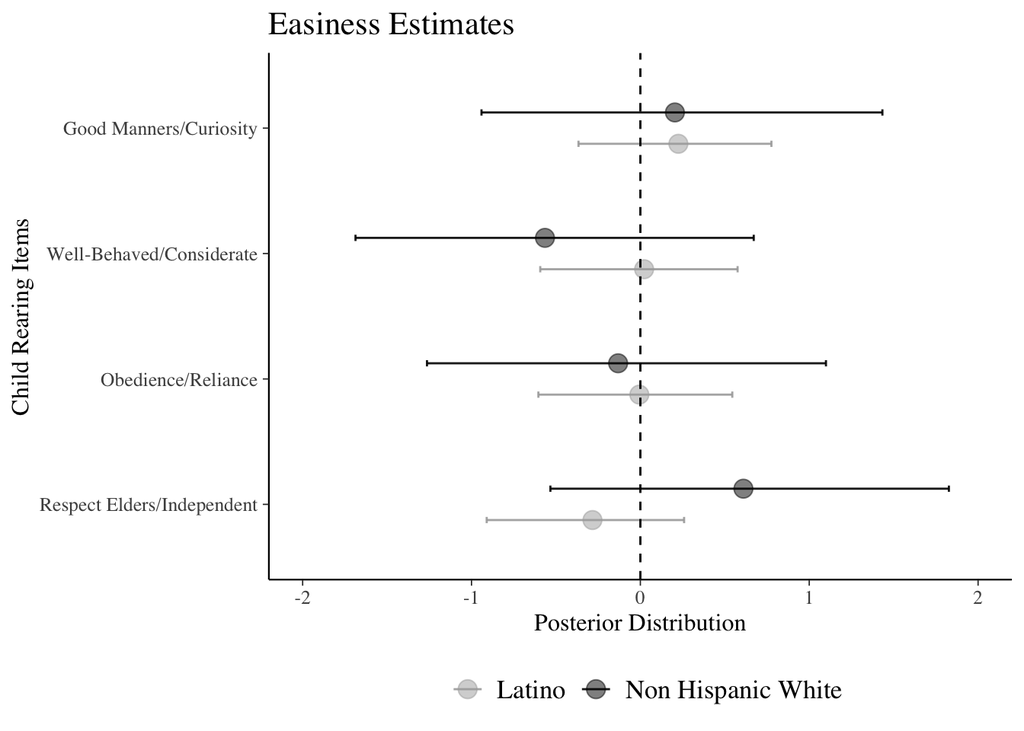

There isn’t much going on with respect to the difficulty/easiness of the items. However, there are more substantial differences with respect to the discrimination values.

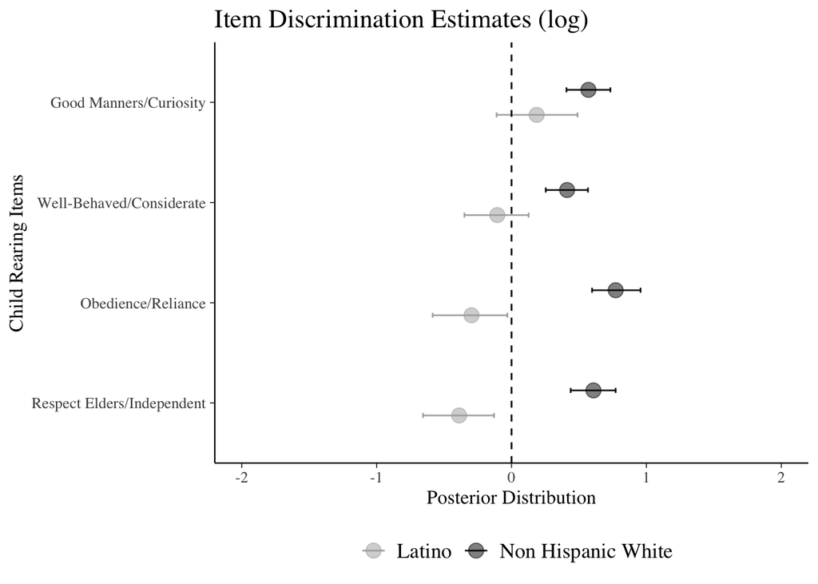

```r
  ggplot(b,
    aes(
    x = factor(item),
    y = mean, ymin = lower,
    ymax = upper, color = race )) +
  geom_point(size = 4, alpha = 0.5, position = position_dodge(width = 0.5)) +
  geom_errorbar(width = .1, alpha = 0.9, position = position_dodge(width = 0.5)) +
  ggtitle("Item Discrimination Estimates (log)") +
  scale_y_continuous("Posterior Distribution", limits = c(-2, 2)) +
  geom_hline(yintercept = 0, colour = "black", linetype = "dashed") +
  scale_colour_manual(name = "", values = c("darkgrey", "black"), labels = c("Latino", "Non Hispanic White")) +
  theme(legend.position = "bottom") +
  coord_flip() +
  # label the item axis with different names
  scale_x_discrete("Child Rearing Items", labels = c("Respect Elders/Independent", "Obedience/Reliance", "Well-Behaved/Considerate", "Good Manners/Curiosity")) +
    theme(
      plot.title = element_text(size = 16, face = "plain")
    )
```

The authoritarian items are more discriminating for non-Hispanic Whites, meaning the items are better at distinguishing between levels of authoritarianism. A similar way of seeing this is to just calculate Cronbach’s alpha for each group

```r
for(race in (c("White", "Hispanic"))){
    print(race)
    psych::alpha(cbind(df$auth1[df$race == race], df$auth2[df$race == race], df$auth3[df$race == race], df$auth4[df$race == race]))$total$raw_alpha %>% print()
}
```

```
## [1] "White"
## [1] 0.6657036
## [1] "Hispanic"
## [1] 0.6177387
```

The alpha estimate is marginally lower for Latinos, suggesting that the items are less discriminating for this group.

Finally, here are the posterior estimates for the mean differences in authoritarianism, using the DIF and non DIF corrected model. Thus far, even though the DIF model is better, there aren’t clear differences – save for the discrimination estimates – that the more complex model is better.

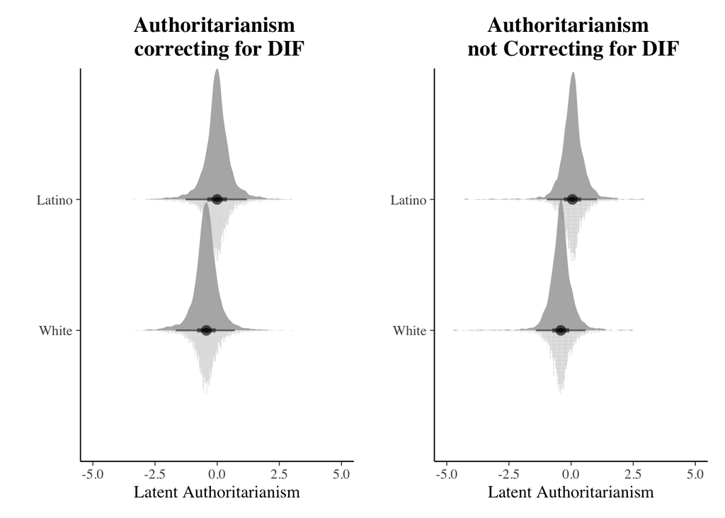

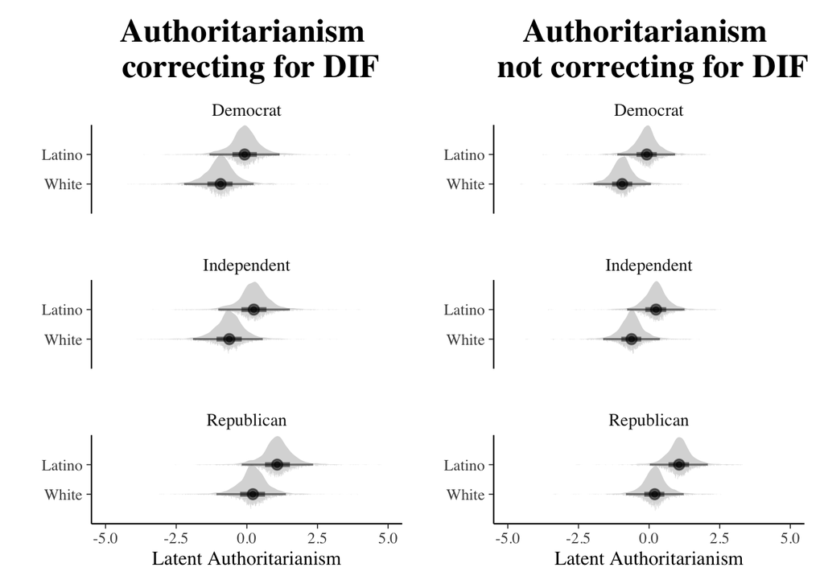

```r
dif1 = spreadDraw(difM1, mean_name = "m1.dif", lower_name = "l1.dif", upper_name = "u1.dif")
dif2 = spreadDraw(difM2, mean_name = "m2.dif", lower_name = "l2.dif", upper_name = "u2.dif")
noDIF = spread_draws(difM4, r_caseid[caseid, ]) %>%
     group_by(caseid) %>%
     summarize(
       mean_name =  mean(r_caseid),
       lower_name = quantile(r_caseid, 0.025),
       upper_name = quantile(r_caseid, 0.975)
      )
#
dat =  df %>%
  left_join(dif1, by = "caseid") %>%
  left_join(dif2, by = "caseid") %>%
  left_join(noDIF, by = "caseid")

dat %>% write.csv(file = "/Users/Chris/Dropbox/masterData/Western_States/git/westernStates/authoritarianismLatino/tmpdata.csv")

dat %>% save(file = "/Users/Chris/Dropbox/masterData/Western_States/git/westernStates/authoritarianismLatino/dataActive.rda")

# gcs_upload_set_limit(300000000L)
# googleCloudStorageR::gcs_upload(file = dat, bucket = "grau_data", name = "dataActive.csv")
```